# Final Project

Sean Burke, Allan Julian, Jared Hayes

# Front Matter

```r
rm(list = ls())
library(tidyverse)
library(boastUtils)
library(ggcorrplot)
library(kableExtra)
library(broom)
library(lme4)

studentDS <- read.csv("StudentSucessDataset.csv")
```

## Introduction (Motivation)

- In today’s dynamic educational landscape, it’s crucial to delve deeper into what influences student graduation and employment outcomes. Our presentation aims to unravel the complexities surrounding this topic by examining various factors that shape students’ paths to success. From demographic data to socioeconomic factors and academic performance indicators, we’ll explore the intricate web of influences that impact student employment prospects.
- The data set we are studying contains 4424 observations, in which each case is a university student. In addition, there are 35 variables that contain a variety of information regarding family, socioeconomics, semester information, and other demographical information.
- Our response variable is `Target`, which describes the status of the students.
- Using the other variables, our goal is to look at the qualities of some of the variables and create models predicting our response.
- Our dataset is cited as: [Valentim Realinho, Jorge Machado, Luís Baptista, & Mónica V. Martins. (2021). Predict students’ dropout and academic success (1.0) [Data set]. Zenodo. https://doi.org/10.5281/zenodo.5777340](https://zenodo.org/records/5777340)

## GLM Section

**Research Questions:**

- What variables are best when predicting the student status `Target`?
- When creating a model with said variables, which are most effective when predicting the student status?

## Explanatory Data Analysis (EDA)

```r
#See couple rows of data
glimpse(studentDS1, 4)
```

```
## Rows: 4,424
## Columns: 35
## $ Marital.status                                 <chr> …
## $ Application.mode                               <chr> …
## $ Application.order                              <int> …
## $ Course                                         <chr> …
## $ Daytime.evening.attendance                     <int> …
## $ Previous.qualification                         <chr> …
## $ Mother.s.qualification                         <chr> …
## $ Father.s.qualification                         <chr> …
## $ Mother.s.occupation                            <chr> …
## $ Father.s.occupation                            <chr> …
## $ Displaced                                      <int> …
## $ Educational.special.needs                      <int> …
## $ Debtor                                         <int> …
```

[output cut: 22 more lines]

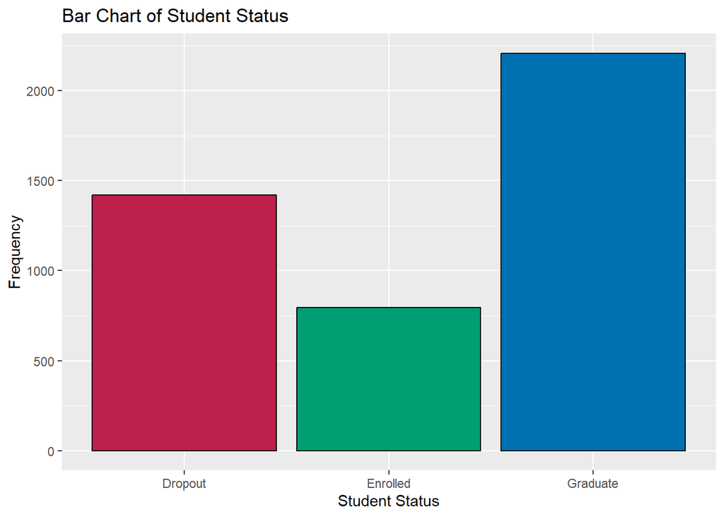

```r
#View Proportion of Student Status
ggplot(
  data = studentDS,
  mapping = aes(x = Target, fill = Target)
) +
  geom_bar(color = "black") +
  scale_fill_manual(values = c(psuPalette[2], boastPalette[3], boastPalette[1])) +
  theme(
    legend.position = "none"
  ) +
  labs(
    title = "Bar Chart of Student Status",
   x = "Student Status",
   y = "Frequency"
  )
```

**Comments:**

- Looking at the status of the students, here are three categories or levels: “Dropout”, “Enrolled”, and “Graduate”.
- If we are interested in creating a predictive model we can create a multinomial model predicting for this status.
- Then, we can find what variables are best in predicting this status

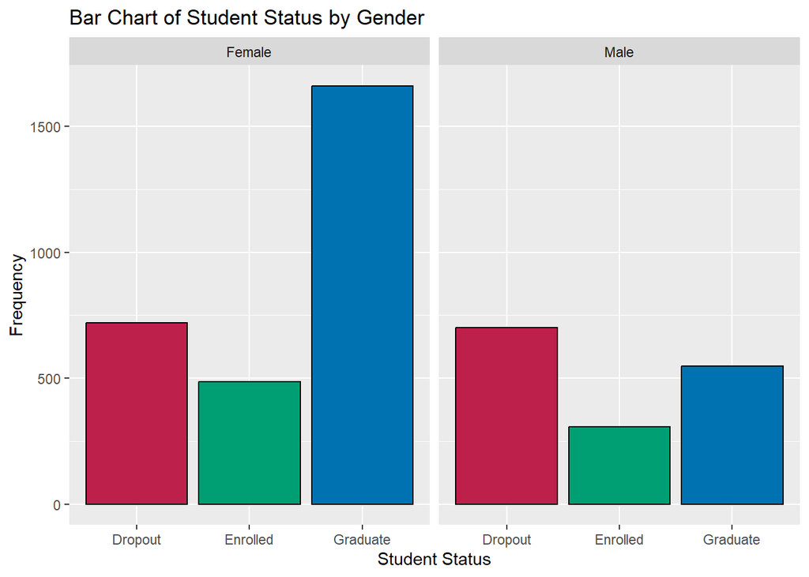

```r
#Create Sex Variable
studentDS <- studentDS %>%
  mutate(sex = ifelse(Gender == 1, "Male", "Female"))
#View Proportion of Student Status
ggplot(
  data = studentDS,
  mapping = aes(x = Target, fill = Target)
) +
  geom_bar(color = "black") +
  facet_wrap(sex ~ .) +
  scale_fill_manual(values = c(psuPalette[2], boastPalette[3], boastPalette[1])) +
    theme(
    legend.position = "none"
  ) +
  labs(
    title = "Bar Chart of Student Status by Gender",
   x = "Student Status",
   y = "Frequency"
  )
```

```r
#View counts and frequency by male and female
studentDS %>%
  group_by(sex) %>%
  summarize(
    N = n(),
    propGrad = NROW(which(Target == "Graduate"))/N,
    propEnroll = NROW(which(Target == "Enrolled"))/N,
    propDrop =  NROW(which(Target == "Dropout"))/N
    ) %>%
  kable()
```

| sex | N | propGrad | propEnroll | propDrop |
| --- | --- | --- | --- | --- |
| Female | 2868 | 0.5791492 | 0.1698047 | 0.2510460 |
| Male | 1556 | 0.3521851 | 0.1973008 | 0.4505141 |

**Comments:**

- Looking at the plots and summary data, we find there is a higher proportion of female graduates than male graduates when comparing the two genders.
- Similarly we find that there are a higher proportion of male dropouts than female dropouts, even though the number of dropouts appear to be similar.
- This indicates that gender may be a good indicator for the student status or success.

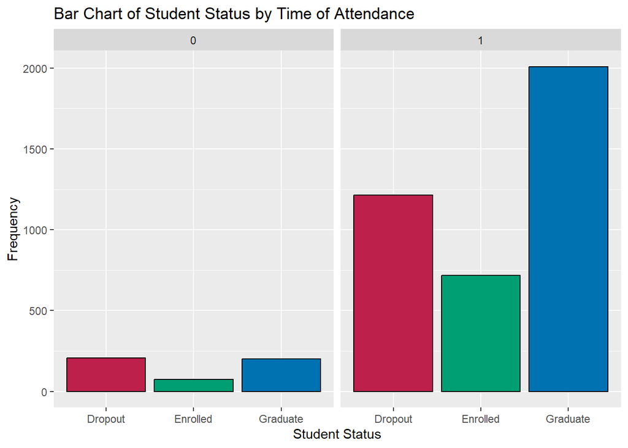

```r
#View Proportion of Student Status by time of attendance
ggplot(
  data = studentDS1,
  mapping = aes(x = Target, fill = Target)
) +
  geom_bar(color = "black") +
  scale_fill_manual(values = c(psuPalette[2], boastPalette[3], boastPalette[1])) +
  theme(
    legend.position = "none"
  ) +
  labs(
    title = "Bar Chart of Student Status by Time of Attendance",
   x = "Student Status",
   y = "Frequency"
  ) +
  facet_wrap(as.factor(Daytime.evening.attendance)~.)
```

```r
  studentDS %>%
    group_by(as.factor(Daytime.evening.attendance)) %>%
    summarize(
      N = n(),
      propGrad = NROW(which(Target == "Graduate"))/N,
      propEnroll = NROW(which(Target == "Enrolled"))/N,
      propDrop =  NROW(which(Target == "Dropout"))/N
    ) %>%
    kable()
```

| as.factor(Daytime.evening.attendance) | N | propGrad | propEnroll | propDrop |
| --- | --- | --- | --- | --- |
| 0 | 483 | 0.4161491 | 0.1552795 | 0.4285714 |
| 1 | 3941 | 0.5095154 | 0.1824410 | 0.3080436 |

`NOTE:` `1` indicates daytime attendance and `0` indicates night time attendance.

**Comments:**

- Here, we see we have a lot more daytime attendance. However, there is a slightly higher proportion of graduates and enrolled and a lesser proportion of dropouts for the daytime group.

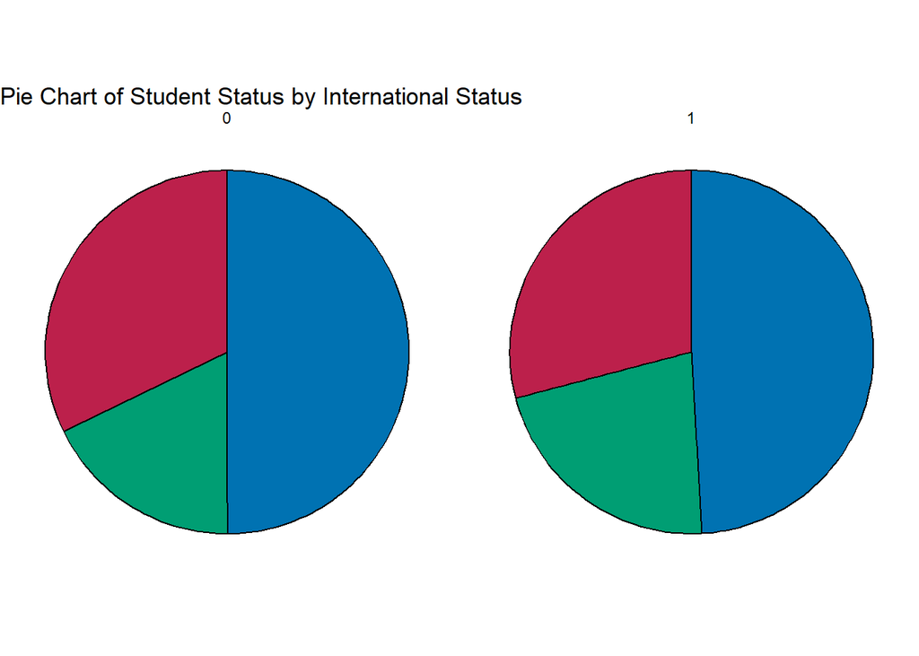

```r
#View Proportion of Student Status
studentDS %>%
  count(International, Target) %>%
  group_by(International) %>%
  mutate(freq = n, total = sum(freq), prop = freq / total) %>%
  ungroup() -> plot_data

# Plot using ggplot2
ggplot(plot_data, aes(x = "", y = prop, fill = Target)) +
  geom_bar(stat = "identity", width = 1, color = "black") +
  coord_polar(theta = "y") +
  facet_wrap(~ International) +
  scale_fill_manual(values = c(psuPalette[2], boastPalette[3], boastPalette[1])) +
  theme_void() +
  theme(legend.position = "none") +
  labs(
    title = "Pie Chart of Student Status by International Status",
    x = NULL,
    y = NULL
  )
```

```r
#View counts and frequency by male and female
studentDS %>%
  group_by(International) %>%
  summarize(
    N = n(),
    propGrad = NROW(which(Target == "Graduate"))/N,
    propEnroll = NROW(which(Target == "Enrolled"))/N,
    propDrop =  NROW(which(Target == "Dropout"))/N
    ) %>%
  kable()
```

| International | N | propGrad | propEnroll | propDrop |
| --- | --- | --- | --- | --- |
| 0 | 4314 | 0.4995364 | 0.1784886 | 0.3219750 |
| 1 | 110 | 0.4909091 | 0.2181818 | 0.2909091 |

**Comments:**

- Here we see a very slightly higher proportion of Non-International graduates.

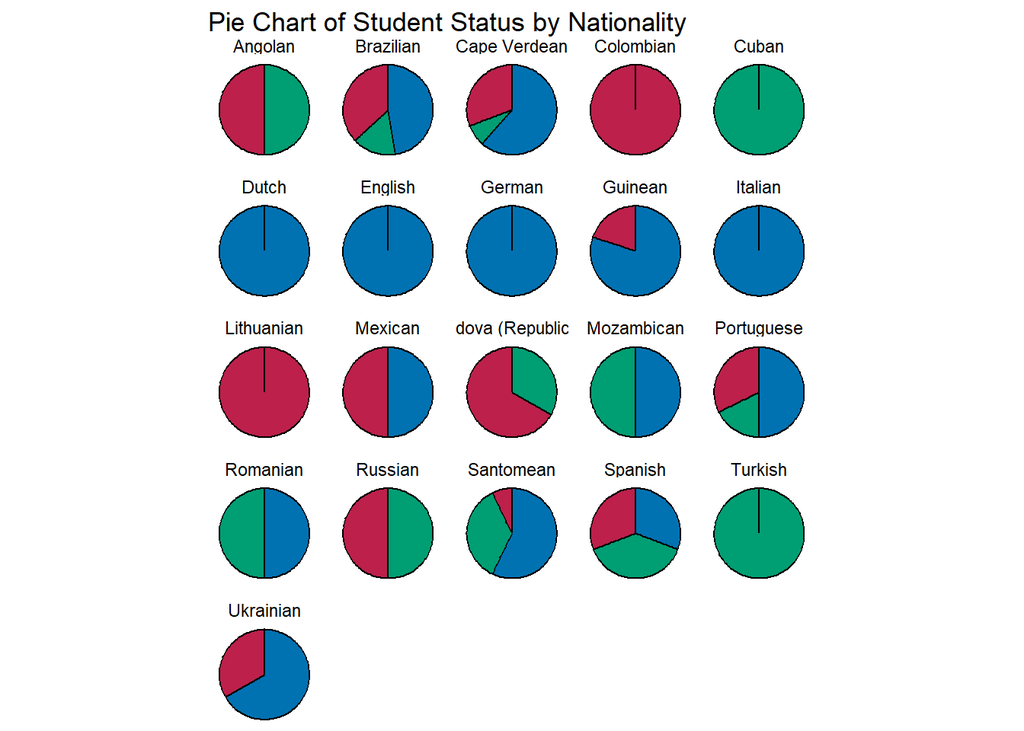

```r
#View Proportion of Student Status
studentDS1 %>%
  count(Nationality, Target) %>%
  group_by(Nationality) %>%
  mutate(freq = n, total = sum(freq), prop = freq / total) %>%
  ungroup() -> plot_data

# Plot using ggplot2
ggplot(plot_data, aes(x = "", y = prop, fill = Target)) +
  geom_bar(stat = "identity", width = 1, color = "black") +
  coord_polar(theta = "y") +
  facet_wrap(~ Nationality) +
  scale_fill_manual(values = c(psuPalette[2], boastPalette[3], boastPalette[1])) +
  theme_void() +
  theme(legend.position = "none") +
  labs(
    title = "Pie Chart of Student Status by Nationality",
    x = NULL,
    y = NULL
  )
```

```r
#View counts and frequency by male and female
studentDS1 %>%
  group_by(Nationality) %>%
  summarize(
    N = n(),
    propGrad = NROW(which(Target == "Graduate"))/N,
    propEnroll = NROW(which(Target == "Enrolled"))/N,
    propDrop =  NROW(which(Target == "Dropout"))/N
    ) %>%
  kable()
```

| Nationality | N | propGrad | propEnroll | propDrop |
| --- | --- | --- | --- | --- |
| Angolan | 2 | 0.0000000 | 0.5000000 | 0.5000000 |
| Brazilian | 38 | 0.4736842 | 0.1578947 | 0.3684211 |
| Cape Verdean | 13 | 0.6153846 | 0.0769231 | 0.3076923 |
| Colombian | 1 | 0.0000000 | 0.0000000 | 1.0000000 |
| Cuban | 1 | 0.0000000 | 1.0000000 | 0.0000000 |
| Dutch | 1 | 1.0000000 | 0.0000000 | 0.0000000 |
| English | 1 | 1.0000000 | 0.0000000 | 0.0000000 |
| German | 2 | 1.0000000 | 0.0000000 | 0.0000000 |
| Guinean | 5 | 0.8000000 | 0.0000000 | 0.2000000 |
| Italian | 3 | 1.0000000 | 0.0000000 | 0.0000000 |
| Lithuanian | 1 | 0.0000000 | 0.0000000 | 1.0000000 |
| Mexican | 2 | 0.5000000 | 0.0000000 | 0.5000000 |
| Moldova (Republic of) | 3 | 0.0000000 | 0.3333333 | 0.6666667 |
| Mozambican | 2 | 0.5000000 | 0.5000000 | 0.0000000 |
| Portuguese | 4314 | 0.4995364 | 0.1784886 | 0.3219750 |
| Romanian | 2 | 0.5000000 | 0.5000000 | 0.0000000 |
| Russian | 2 | 0.0000000 | 0.5000000 | 0.5000000 |
| Santomean | 14 | 0.5714286 | 0.3571429 | 0.0714286 |
| Spanish | 13 | 0.3076923 | 0.3846154 | 0.3076923 |
| Turkish | 1 | 0.0000000 | 1.0000000 | 0.0000000 |
| Ukrainian | 3 | 0.6666667 | 0.0000000 | 0.3333333 |

**Comments:**

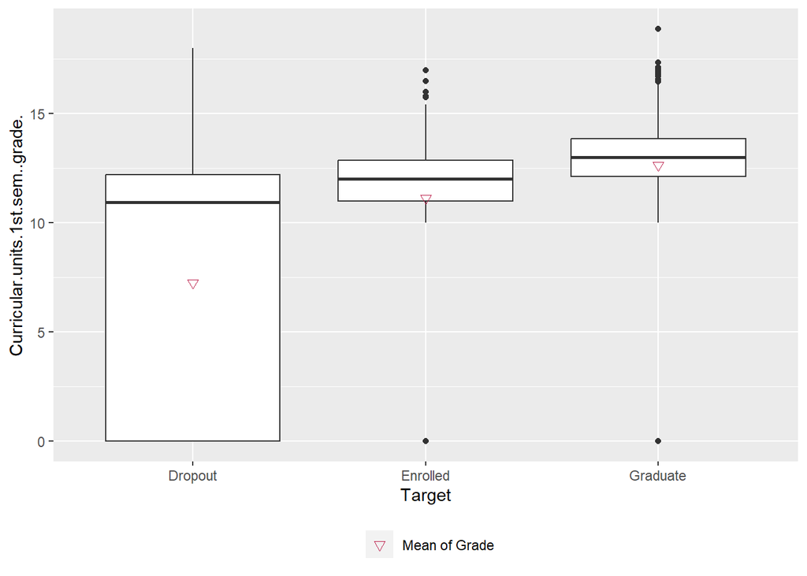

```r
#Calculate means
meanGrade1 <- studentDS %>%
  group_by(Target) %>%
  summarize(
    N = n(),
    avgGrade = mean(Curricular.units.1st.sem..grade.)
  )

#Box plot for 1st semester
ggplot(
  data = studentDS1,
  mapping = aes(x = Target, y = Curricular.units.1st.sem..grade.)
  ) +
    geom_boxplot() +
  geom_point(
    data = meanGrade1,
    mapping = aes(x = Target, y = avgGrade, color = "Mean of Grade"),
    shape = 6,
    size = 2
  ) +
  scale_color_manual(values = psuPalette[2], name = "", labels = "Mean of Grade") +
  theme(legend.position = "bottom")
```

```r
studentDS %>%
    group_by(Target) %>%
    summarize(
      N = n(),
      minGrade = min(Curricular.units.1st.sem..grade.),
      avgGrade = mean(Curricular.units.1st.sem..grade.),
      medianGrade = median(Curricular.units.1st.sem..grade.),
      maxGrade = max(Curricular.units.1st.sem..grade.)
    ) %>%
    kable()
```

| Target | N | minGrade | avgGrade | medianGrade | maxGrade |
| --- | --- | --- | --- | --- | --- |
| Dropout | 1421 | 0 | 7.256655 | 10.92857 | 18.000 |
| Enrolled | 794 | 0 | 11.125257 | 12.00000 | 17.000 |
| Graduate | 2209 | 0 | 12.643655 | 13.00000 | 18.875 |

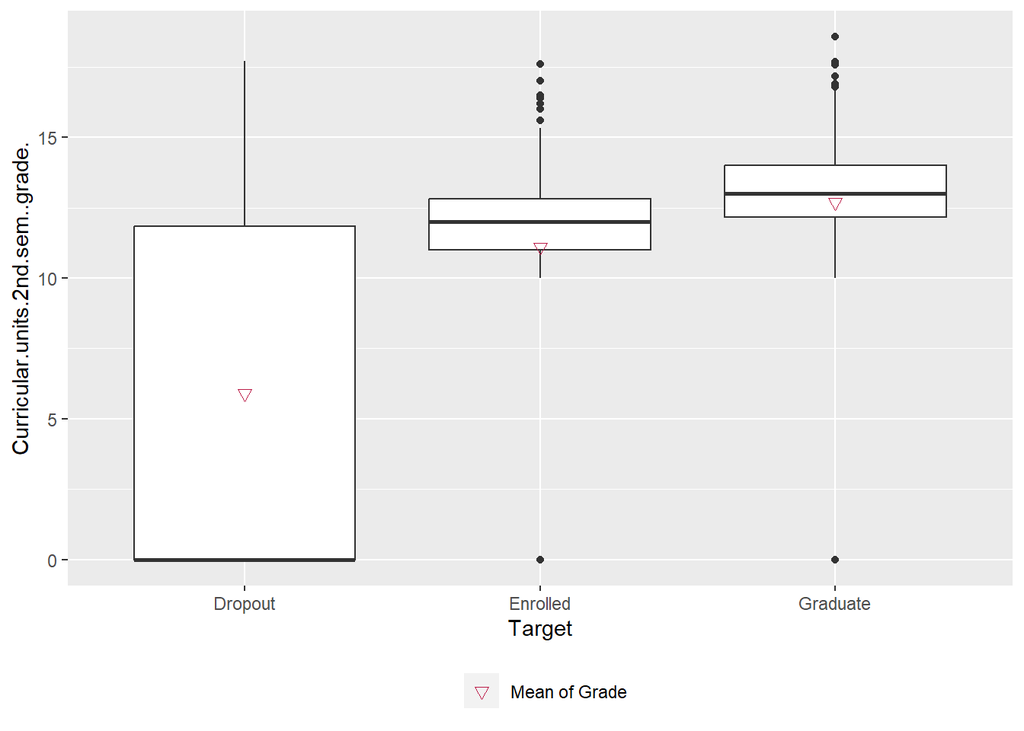

```r
#Calculate means
meanGrade2 <- studentDS %>%
  group_by(Target) %>%
  summarize(
    N = n(),
    avgGrade = mean(Curricular.units.2nd.sem..grade.)
  )

#Box plot for 2nd semester
ggplot(
  data = studentDS1,
  mapping = aes(x = Target, y = Curricular.units.2nd.sem..grade.)
  ) +
    geom_boxplot() +
  geom_point(
    data = meanGrade2,
    mapping = aes(x = Target, y = avgGrade, color = "Mean of Grade"),
    shape = 6,
    size = 2
  ) +
  scale_color_manual(values = psuPalette[2], name = "", labels = "Mean of Grade") +
  theme(legend.position = "bottom")
```

```r
studentDS %>%
    group_by(Target) %>%
    summarize(
      N = n(),
      minGrade = min(Curricular.units.2nd.sem..grade.),
      avgGrade = mean(Curricular.units.2nd.sem..grade.),
      medianGrade = median(Curricular.units.2nd.sem..grade.),
      maxGrade = max(Curricular.units.2nd.sem..grade.)
    ) %>%
    kable()
```

| Target | N | minGrade | avgGrade | medianGrade | maxGrade |
| --- | --- | --- | --- | --- | --- |
| Dropout | 1421 | 0 | 5.899339 | 0 | 17.71429 |
| Enrolled | 794 | 0 | 11.117364 | 12 | 17.60000 |
| Graduate | 2209 | 0 | 12.697276 | 13 | 18.57143 |

**Comments:**

- Looking at the box plots for the 2 semester’s there is a similar trend between the distributions of the grades of the students for each status group.
- Dropouts tended to score lower than the graduates, with the enrolled students performing between the two.
- The summary tables reflect this trend as well, where the average grade is lowest in the dropout group and highest in the graduated group.

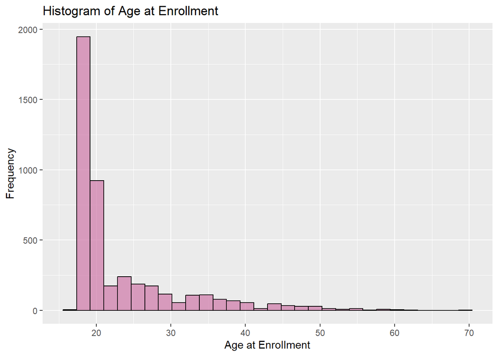

```r
#Distribution of Age
ggplot(
  data = studentDS,
  mapping = aes(x = Age.at.enrollment)
  ) +
    geom_histogram(
      color = "black",
      fill = boastPalette[4],
      alpha = 0.7
    ) +
  labs(
    title = "Histogram of Age at Enrollment",
    x = "Age at Enrollment",
    y = "Frequency"
  )
```

**Comments:**

- Here we see a right-skewed distribution.
- The median age is `20` years old with Some very extreme value at the right (`70`).

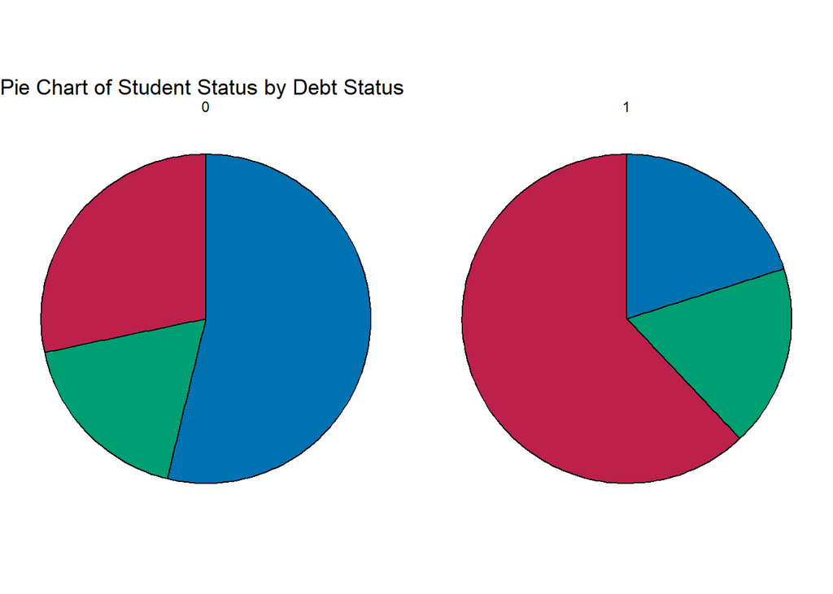

```r
#View Proportion of Student Status
studentDS %>%
  count(Debtor, Target) %>%
  group_by(Debtor) %>%
  mutate(freq = n, total = sum(freq), prop = freq / total) %>%
  ungroup() -> plot_data

# Plot using ggplot2
ggplot(plot_data, aes(x = "", y = prop, fill = Target)) +
  geom_bar(stat = "identity", width = 1, color = "black") +
  coord_polar(theta = "y") +
  facet_wrap(~ Debtor) +
  scale_fill_manual(values = c(psuPalette[2], boastPalette[3], boastPalette[1])) +
  theme_void() +
  theme(legend.position = "none") +
  labs(
    title = "Pie Chart of Student Status by Debt Status",
    x = NULL,
    y = NULL
  )
```

```r
#View counts and frequency by male and female
studentDS %>%
  group_by(International) %>%
  summarize(
    N = n(),
    propGrad = NROW(which(Target == "Graduate"))/N,
    propEnroll = NROW(which(Target == "Enrolled"))/N,
    propDrop =  NROW(which(Target == "Dropout"))/N
    ) %>%
  kable()
```

[output not shown]

**Comments:**

- Intuitively, we see students with more debt tend to exhibit a higher proportion of drop-out.

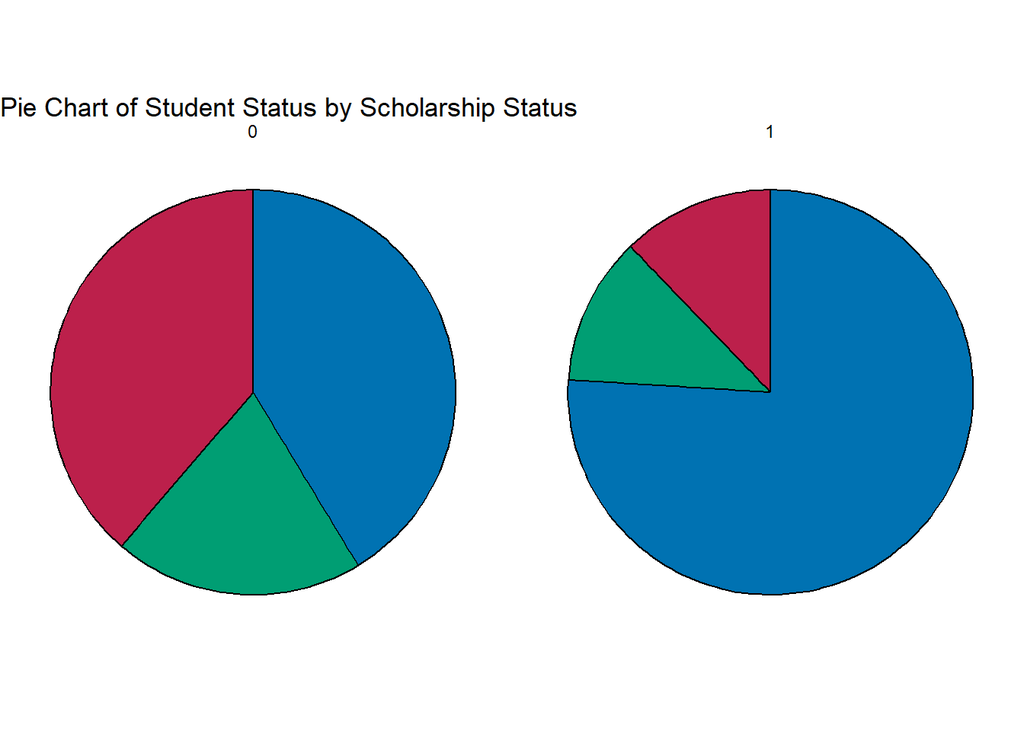

```r
#View Proportion of Student Status
studentDS %>%
  count(Scholarship.holder, Target) %>%
  group_by(Scholarship.holder) %>%
  mutate(freq = n, total = sum(freq), prop = freq / total) %>%
  ungroup() -> plot_data

# Plot using ggplot2
ggplot(plot_data, aes(x = "", y = prop, fill = Target)) +
  geom_bar(stat = "identity", width = 1, color = "black") +
  coord_polar(theta = "y") +
  facet_wrap(~ Scholarship.holder) +
  scale_fill_manual(values = c(psuPalette[2], boastPalette[3], boastPalette[1])) +
  theme_void() +
  theme(legend.position = "none") +
  labs(
    title = "Pie Chart of Student Status by Scholarship Status",
    x = NULL,
    y = NULL
  )
```

```r
#View counts and frequency
studentDS %>%
  group_by(Scholarship.holder) %>%
  summarize(
    N = n(),
    propGrad = NROW(which(Target == "Graduate"))/N,
    propEnroll = NROW(which(Target == "Enrolled"))/N,
    propDrop =  NROW(which(Target == "Dropout"))/N
    ) %>%
  kable()
```

| Scholarship.holder | N | propGrad | propEnroll | propDrop |
| --- | --- | --- | --- | --- |
| 0 | 3325 | 0.4132331 | 0.1996992 | 0.3870677 |
| 1 | 1099 | 0.7597816 | 0.1182894 | 0.1219290 |

`NOTE:` `1` indicates the student has some sort of scholarship and `0` indicates the student is not a scholarship holder.

**Comments:**

- We see scholarship holders have a higher proportion of Graduates, which is expected.

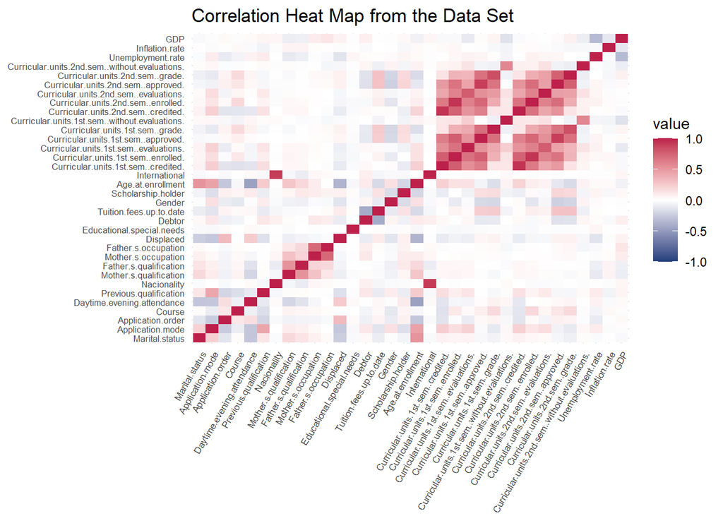

```r
library(reshape2)

# Calculate correlation matrix
corMat <- cor(studentDS %>% dplyr::select(!Target & !sex), use = "complete.obs")

# Melt the correlation matrix
corMelted <- melt(corMat)

# Plotting the heatmap
ggplot(
  data = corMelted,
  mapping = aes(x = Var1, y = Var2, fill = value)
) +
  geom_tile() +
  scale_fill_gradient2(
    low = psuPalette[1],
    high = psuPalette[2],
    mid = "white",
    midpoint = 0,
    limit = c(-1, 1)
  ) +
  theme_minimal() +
  theme(
    axis.text.x = element_text(angle = 60, hjust = 1, vjust = 1, size = 6.3),
    axis.text.y = element_text(size = 6.5),
    axis.title = element_blank()
  ) +
  labs(
    title = "Correlation Heat Map from the Data Set"
  )
```

**Comments:**

- Looking at the heat map, we find strong correlations present between the credits, grades, and other curricular data recorded for the 1st and 2nd semesters.
- We can also see some correlation between the parent’s data, as well as correlation between certain groups along the diagonal.
- There is a relatively strong correlation between whether the student is an Internation and their nationality.
- If we separate those areas of correlation into groups We can also see some correlation between groups as well, which should be kept in mind when modeling.

## Multinomial Model

- For our Generalized Linear Model (GLM), we will be creating a Multinomial Logistic Regression Model due to the 3 levels of our response.
- First we will perform a variable selection to find the best predictors for our model. Then, we will build our model using the variables selected. After, we will assess our model using overall accuracy as our indicator.

### Load Additional Libraries

```r
library(nnet)
library(MASS)
```

### Variable Selection

**Initial Comments:**

- We will perform a backwards feature selection based on AIC criterion, because we are interested in making predictions.
- We are interested in minimizing our model complexity. And, this is method is automatic.

```r
#Build full and base models
baseModel <-  multinom(Target ~ 1, data = studentDS)
fullModel <- multinom(Target ~ Marital.status + Application.mode + Application.order +
    Course + Daytime.evening.attendance + Previous.qualification +
    Nacionality + (Mother.s.qualification + Father.s.qualification +
    Mother.s.occupation + Father.s.occupation)^2 + Displaced + Educational.special.needs +
    (Debtor + Tuition.fees.up.to.date)^2 + Gender + Scholarship.holder +
    Age.at.enrollment + International + Curricular.units.1st.sem..credited. +
    (Curricular.units.1st.sem..enrolled. + Curricular.units.1st.sem..evaluations. +
    Curricular.units.1st.sem..approved. + Curricular.units.1st.sem..grade. +
    Curricular.units.1st.sem..without.evaluations.)^2 + (Curricular.units.2nd.sem..credited. +
    Curricular.units.2nd.sem..enrolled. + Curricular.units.2nd.sem..evaluations. +
    Curricular.units.2nd.sem..approved. + Curricular.units.2nd.sem..grade. +
    Curricular.units.2nd.sem..without.evaluations.)^2 + Unemployment.rate +
    Inflation.rate + GDP + International:Nacionality, data = studentDS)
```

**Comments:**

`NOTE:` Given the Nuances in the Data (as seen in the correlation heatmap), it is a good practice to account for interaction terms when building the model.

- Our Initial model before the feature selection included `34` Main Effects and `33` Interactions.
- After performing the backwards selection we ended up with `25` Main Effects and `13` Interactions.

### Modeling

**Initial Comments:**

- Using the selected predictors we will create a multinomial model using the `multinom` function.

```r
#Model using variables selected using backwards selection
bsModel <- multinom(Target ~ Application.order + Course + Nacionality + Mother.s.qualification +
    Father.s.qualification + Mother.s.occupation + Father.s.occupation +
    Displaced + Debtor + Tuition.fees.up.to.date + Gender + Scholarship.holder +
    Age.at.enrollment + International + Curricular.units.1st.sem..credited. +
    Curricular.units.1st.sem..enrolled. + Curricular.units.1st.sem..approved. +
    Curricular.units.1st.sem..without.evaluations. + Curricular.units.2nd.sem..credited. +
    Curricular.units.2nd.sem..enrolled. + Curricular.units.2nd.sem..evaluations. +
    Curricular.units.2nd.sem..approved. + Curricular.units.2nd.sem..grade. +
    Curricular.units.2nd.sem..without.evaluations. + Unemployment.rate +
    Mother.s.qualification:Mother.s.occupation + Mother.s.occupation:Father.s.occupation +
    Curricular.units.1st.sem..enrolled.:Curricular.units.1st.sem..without.evaluations. +
    Curricular.units.1st.sem..approved.:Curricular.units.1st.sem..without.evaluations. +
    Curricular.units.2nd.sem..credited.:Curricular.units.2nd.sem..evaluations. +
    Curricular.units.2nd.sem..credited.:Curricular.units.2nd.sem..approved. +
    Curricular.units.2nd.sem..credited.:Curricular.units.2nd.sem..without.evaluations. +
    Curricular.units.2nd.sem..enrolled.:Curricular.units.2nd.sem..evaluations. +
    Curricular.units.2nd.sem..enrolled.:Curricular.units.2nd.sem..approved. +
    Curricular.units.2nd.sem..enrolled.:Curricular.units.2nd.sem..without.evaluations. +
    Curricular.units.2nd.sem..evaluations.:Curricular.units.2nd.sem..approved. +
    Curricular.units.2nd.sem..evaluations.:Curricular.units.2nd.sem..without.evaluations. +
    Curricular.units.2nd.sem..approved.:Curricular.units.2nd.sem..grade., data = studentDS)
#Summary Table
tidy(bsModel, conf.int = FALSE, exponentiate = FALSE) %>%
  kable(digits = 3, format = "markdown")
```

| y.level | term | estimate | std.error | statistic | p.value |
| --- | --- | --- | --- | --- | --- |
| Enrolled | (Intercept) | 0.030 | 0.512 | 0.059 | 0.953 |
| Enrolled | Application.order | -0.116 | 0.048 | -2.413 | 0.016 |
| Enrolled | Course | -0.069 | 0.015 | -4.650 | 0.000 |
| Enrolled | Nacionality | -0.158 | 0.049 | -3.240 | 0.001 |
| Enrolled | Mother.s.qualification | -0.058 | 0.015 | -3.855 | 0.000 |
| Enrolled | Father.s.qualification | 0.000 | 0.006 | -0.002 | 0.999 |
| Enrolled | Mother.s.occupation | 0.001 | 0.032 | 0.023 | 0.981 |
| Enrolled | Father.s.occupation | 0.018 | 0.026 | 0.675 | 0.500 |
| Enrolled | Displaced | -0.330 | 0.126 | -2.631 | 0.009 |
| Enrolled | Debtor | -0.259 | 0.177 | -1.468 | 0.142 |
| Enrolled | Tuition.fees.up.to.date | 2.014 | 0.202 | 9.980 | 0.000 |
| Enrolled | Gender | -0.239 | 0.117 | -2.049 | 0.040 |
| Enrolled | Scholarship.holder | 0.051 | 0.161 | 0.315 | 0.753 |
| Enrolled | Age.at.enrollment | -0.043 | 0.009 | -4.751 | 0.000 |
| Enrolled | International | 2.354 | 0.465 | 5.061 | 0.000 |
| Enrolled | Curricular.units.1st.sem..credited. | -0.023 | 0.096 | -0.244 | 0.808 |
| Enrolled | Curricular.units.1st.sem..enrolled. | -0.023 | 0.115 | -0.204 | 0.838 |
| Enrolled | Curricular.units.1st.sem..approved. | 0.080 | 0.048 | 1.653 | 0.098 |
| Enrolled | Curricular.units.1st.sem..without.evaluations. | 0.164 | 0.332 | 0.494 | 0.621 |
| Enrolled | Curricular.units.2nd.sem..credited. | -0.373 | 0.192 | -1.944 | 0.052 |
| Enrolled | Curricular.units.2nd.sem..enrolled. | -0.327 | 0.129 | -2.530 | 0.011 |
| Enrolled | Curricular.units.2nd.sem..evaluations. | 0.209 | 0.078 | 2.697 | 0.007 |
| Enrolled | Curricular.units.2nd.sem..approved. | 0.964 | 0.202 | 4.760 | 0.000 |
| Enrolled | Curricular.units.2nd.sem..grade. | 0.079 | 0.023 | 3.400 | 0.001 |
| Enrolled | Curricular.units.2nd.sem..without.evaluations. | -1.079 | 0.491 | -2.199 | 0.028 |
| Enrolled | Unemployment.rate | -0.085 | 0.022 | -3.886 | 0.000 |
| Enrolled | Mother.s.qualification:Mother.s.occupation | 0.004 | 0.002 | 2.509 | 0.012 |
| Enrolled | Mother.s.occupation:Father.s.occupation | 0.001 | 0.001 | 0.800 | 0.424 |
| Enrolled | Curricular.units.1st.sem..enrolled.:Curricular.units.1st.sem..without.evaluations. | -0.018 | 0.054 | -0.340 | 0.734 |
| Enrolled | Curricular.units.1st.sem..approved.:Curricular.units.1st.sem..without.evaluations. | -0.059 | 0.036 | -1.639 | 0.101 |
| Enrolled | Curricular.units.2nd.sem..credited.:Curricular.units.2nd.sem..evaluations. | 0.032 | 0.015 | 2.125 | 0.034 |
| Enrolled | Curricular.units.2nd.sem..credited.:Curricular.units.2nd.sem..approved. | -0.023 | 0.022 | -1.054 | 0.292 |
| Enrolled | Curricular.units.2nd.sem..credited.:Curricular.units.2nd.sem..without.evaluations. | -0.171 | 0.097 | -1.768 | 0.077 |
| Enrolled | Curricular.units.2nd.sem..enrolled.:Curricular.units.2nd.sem..evaluations. | -0.017 | 0.013 | -1.340 | 0.180 |
| Enrolled | Curricular.units.2nd.sem..enrolled.:Curricular.units.2nd.sem..approved. | 0.014 | 0.023 | 0.611 | 0.541 |
| Enrolled | Curricular.units.2nd.sem..enrolled.:Curricular.units.2nd.sem..without.evaluations. | 0.228 | 0.068 | 3.352 | 0.001 |
| Enrolled | Curricular.units.2nd.sem..evaluations.:Curricular.units.2nd.sem..approved. | -0.006 | 0.010 | -0.588 | 0.557 |
| Enrolled | Curricular.units.2nd.sem..evaluations.:Curricular.units.2nd.sem..without.evaluations. | -0.026 | 0.025 | -1.015 | 0.310 |
| Enrolled | Curricular.units.2nd.sem..approved.:Curricular.units.2nd.sem..grade. | -0.048 | 0.012 | -4.055 | 0.000 |
| Graduate | (Intercept) | 0.330 | 0.549 | 0.601 | 0.548 |
| Graduate | Application.order | -0.088 | 0.048 | -1.824 | 0.068 |
| Graduate | Course | -0.120 | 0.016 | -7.338 | 0.000 |
| Graduate | Nacionality | -0.257 | 0.043 | -6.017 | 0.000 |
| Graduate | Mother.s.qualification | -0.032 | 0.016 | -1.997 | 0.046 |
| Graduate | Father.s.qualification | 0.011 | 0.006 | 1.669 | 0.095 |
| Graduate | Mother.s.occupation | -0.008 | 0.035 | -0.238 | 0.812 |
| Graduate | Father.s.occupation | -0.034 | 0.028 | -1.198 | 0.231 |
| Graduate | Displaced | -0.305 | 0.135 | -2.254 | 0.024 |
| Graduate | Debtor | -1.019 | 0.216 | -4.711 | 0.000 |
| Graduate | Tuition.fees.up.to.date | 3.139 | 0.278 | 11.304 | 0.000 |
| Graduate | Gender | -0.492 | 0.126 | -3.891 | 0.000 |
| Graduate | Scholarship.holder | 0.730 | 0.155 | 4.707 | 0.000 |
| Graduate | Age.at.enrollment | -0.047 | 0.009 | -4.999 | 0.000 |
| Graduate | International | 3.579 | 0.366 | 9.788 | 0.000 |
| Graduate | Curricular.units.1st.sem..credited. | -0.241 | 0.101 | -2.385 | 0.017 |
| Graduate | Curricular.units.1st.sem..enrolled. | -0.286 | 0.126 | -2.269 | 0.023 |
| Graduate | Curricular.units.1st.sem..approved. | 0.755 | 0.068 | 11.101 | 0.000 |
| Graduate | Curricular.units.1st.sem..without.evaluations. | -0.677 | 0.285 | -2.374 | 0.018 |
| Graduate | Curricular.units.2nd.sem..credited. | -0.180 | 0.208 | -0.868 | 0.385 |
| Graduate | Curricular.units.2nd.sem..enrolled. | -1.222 | 0.219 | -5.577 | 0.000 |
| Graduate | Curricular.units.2nd.sem..evaluations. | -0.239 | 0.103 | -2.333 | 0.020 |
| Graduate | Curricular.units.2nd.sem..approved. | 1.772 | 0.232 | 7.649 | 0.000 |
| Graduate | Curricular.units.2nd.sem..grade. | 0.044 | 0.058 | 0.763 | 0.446 |
| Graduate | Curricular.units.2nd.sem..without.evaluations. | 0.266 | 0.572 | 0.466 | 0.641 |
| Graduate | Unemployment.rate | -0.094 | 0.023 | -4.025 | 0.000 |
| Graduate | Mother.s.qualification:Mother.s.occupation | 0.003 | 0.002 | 1.605 | 0.109 |
| Graduate | Mother.s.occupation:Father.s.occupation | 0.003 | 0.001 | 2.008 | 0.045 |
| Graduate | Curricular.units.1st.sem..enrolled.:Curricular.units.1st.sem..without.evaluations. | 0.244 | 0.044 | 5.498 | 0.000 |
| Graduate | Curricular.units.1st.sem..approved.:Curricular.units.1st.sem..without.evaluations. | -0.242 | 0.039 | -6.259 | 0.000 |
| Graduate | Curricular.units.2nd.sem..credited.:Curricular.units.2nd.sem..evaluations. | -0.013 | 0.016 | -0.824 | 0.410 |
| Graduate | Curricular.units.2nd.sem..credited.:Curricular.units.2nd.sem..approved. | 0.028 | 0.022 | 1.255 | 0.209 |
| Graduate | Curricular.units.2nd.sem..credited.:Curricular.units.2nd.sem..without.evaluations. | 0.166 | 0.098 | 1.693 | 0.091 |
| Graduate | Curricular.units.2nd.sem..enrolled.:Curricular.units.2nd.sem..evaluations. | 0.061 | 0.016 | 3.761 | 0.000 |
| Graduate | Curricular.units.2nd.sem..enrolled.:Curricular.units.2nd.sem..approved. | -0.050 | 0.027 | -1.877 | 0.060 |
| Graduate | Curricular.units.2nd.sem..enrolled.:Curricular.units.2nd.sem..without.evaluations. | -0.161 | 0.095 | -1.700 | 0.089 |
| Graduate | Curricular.units.2nd.sem..evaluations.:Curricular.units.2nd.sem..approved. | -0.039 | 0.016 | -2.474 | 0.013 |
| Graduate | Curricular.units.2nd.sem..evaluations.:Curricular.units.2nd.sem..without.evaluations. | 0.061 | 0.029 | 2.118 | 0.034 |
| Graduate | Curricular.units.2nd.sem..approved.:Curricular.units.2nd.sem..grade. | 0.002 | 0.014 | 0.173 | 0.862 |

**Comments:**

- The formula’s for the multinomial model are as follows:

**Enrolled vs Dropout:**

**Graduate vs Dropout:**

**Comments:**

- Looking at the summary table the most effective predictor present in the model is `International` with a p-values of `0`, as well as a coefficient with magnitude of `2.354` and `3.579` when considering Enrolled vs. Dropout and Graduate and Graduate vs. Dropout respectively.
- If we look back at our EDA, our `International` variable seemed to have little effect.
- While we don’t know for sure without sufficient data, there is a high possibility of confounding variables or other factors that influenced this.
- *Interpretations:* The odds that a student is enrolled vs dropped out, after controlling for the other variables change by a factor of `10.5276` as we move from non-international to international status. Likewise, the odds that a student is graduated vs dropped out, after controlling for the other variables change by a factor of `35.83769` as we move from non-international to international status.

### Model Assessement

```r
#Create Conf Matrix
predClass <- predict(bsModel, newData = studentDS, type = "class")

table(predClass, studentDS$Target)
```

```
##
## predClass  Dropout Enrolled Graduate
##   Dropout     1090      167       66
##   Enrolled     146      304       93
##   Graduate     185      323     2050
```

```r
#Calculate Total Accuracy
(1090 + 304 + 2050) / nrow(studentDS)
```

```
## [1] 0.778481
```

**Comments:**

- Looking at the confusion matrix, we obtain an overall accuracy of 77.8481%

## Additional Model

- To further enhance our predictions, we are interested in implementing other machine learning techniques
- Because of the high volume of categorical data and interactions, we were interested in seeing if using decision trees would be beneficial.
- Specifically we will be using a bagging (bootstrap aggregated) technique call random foresting.

### Load Additional Libraries

```r
library(randomForest)
```

### Variable Selection

- For this model, we will use only the main effects selected in our multinomial model, since random forest decision trees handle interactions well.

### Modeling/Assessment

```r
#Create Random Forest Object
rf.object <- randomForest(as.factor(Target) ~ Application.order + Course + Nacionality + Mother.s.qualification +
    Father.s.qualification + Mother.s.occupation + Father.s.occupation +
    Displaced + Debtor + Tuition.fees.up.to.date + Gender + Scholarship.holder +
    Age.at.enrollment + International + Curricular.units.1st.sem..credited. +
    Curricular.units.1st.sem..enrolled. + Curricular.units.1st.sem..approved. +
    Curricular.units.1st.sem..without.evaluations. + Curricular.units.2nd.sem..credited. +
    Curricular.units.2nd.sem..enrolled. + Curricular.units.2nd.sem..evaluations. +
    Curricular.units.2nd.sem..approved. + Curricular.units.2nd.sem..grade. +
    Curricular.units.2nd.sem..without.evaluations. + Unemployment.rate,
    data = studentDS)
```

```r
#Display Information including Confusion matrix and Importance
rf.object
```

```
##
## Call:
##  randomForest(formula = as.factor(Target) ~ Application.order +      Course + Nacionality + Mother.s.qualification + Father.s.qualification +      Mother.s.occupation + Father.s.occupation + Displaced + Debtor +      Tuition.fees.up.to.date + Gender + Scholarship.holder + Age.at.enrollment +     …
##                Type of random forest: classification
##                      Number of trees: 500
## No. of variables tried at each split: 5
##
##         OOB estimate of  error rate: 21.99%
## Confusion matrix:
##          Dropout Enrolled Graduate class.error
## Dropout     1085      131      205  0.23645320
## Enrolled     166      309      319  0.61083123
## Graduate      56       96     2057  0.06880942
```

```r
rf.object$importance
```

```
##                                                MeanDecreaseGini
## Application.order                                     59.484485
## Course                                               127.696130
## Nacionality                                            8.345622
## Mother.s.qualification                                86.647446
## Father.s.qualification                                86.154901
## Mother.s.occupation                                  104.438227
## Father.s.occupation                                  116.891549
## Displaced                                             33.873919
## Debtor                                                36.760571
## Tuition.fees.up.to.date                              130.666946
## Gender                                                39.584313
## Scholarship.holder                                    52.727951
## Age.at.enrollment                                    149.717602
## International                                          5.595464
## Curricular.units.1st.sem..credited.                   27.376491
## Curricular.units.1st.sem..enrolled.                   70.231555
## Curricular.units.1st.sem..approved.                  295.664717
## Curricular.units.1st.sem..without.evaluations.        20.660366
## Curricular.units.2nd.sem..credited.                   22.738265
## Curricular.units.2nd.sem..enrolled.                   74.077925
## Curricular.units.2nd.sem..evaluations.               157.903712
## Curricular.units.2nd.sem..approved.                  485.125476
## Curricular.units.2nd.sem..grade.                     337.033305
## Curricular.units.2nd.sem..without.evaluations.        19.010856
## Unemployment.rate                                    115.380774
```

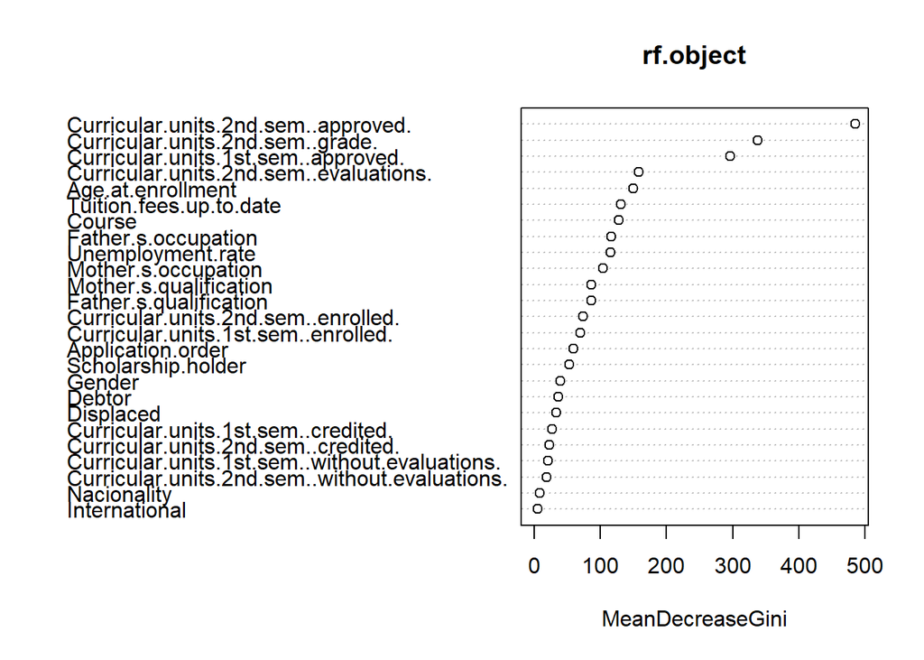

```r
varImpPlot(rf.object)
```

**Comments:**

## MultiLevel Modeling Section

**Variable of Interest:** `Unemployment.rate`

- Unemployment rates with the model will allow us to pinpoint demographic and socioeconomic factors.
- Analyzing unemployment rates using a robust statistical model fosters institutional accountability.
- The relationship between unemployment rates and academic performance indicators will help provide insights into the factors driving student success (our target variable).
- Insights gained from analyzing unemployment rates can hopefully be used to inform the development of effective policies and programs aimed at reducing student unemployment.

### EDA (Multilevel)

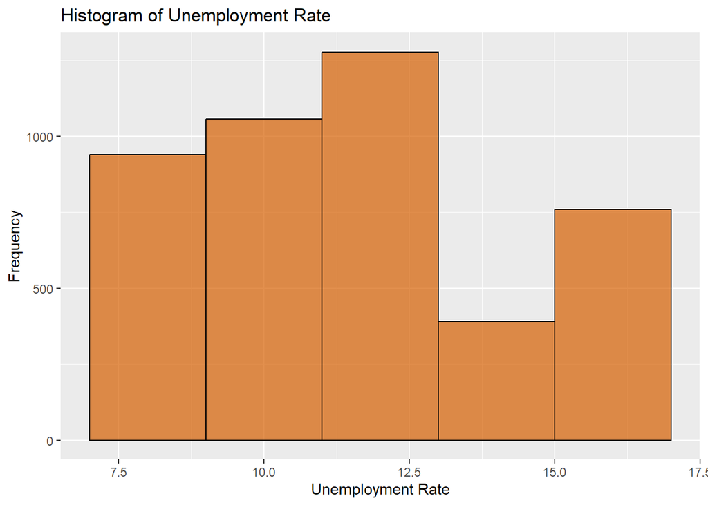

```r
#View unemployment rate
ggplot(
  data = studentDS,
  mapping = aes(x = Unemployment.rate)
) +
  geom_histogram(
    color = "black",
    fill = boastPalette[2],
    alpha = 0.7,
    binwidth = 2
  ) +
  labs(
    title = "Histogram of Unemployment Rate",
   x = "Unemployment Rate",
   y = "Frequency"
  )
```

**Comments:**

- Here we see a slightly right-skewed, with the data being most frequent around 12%

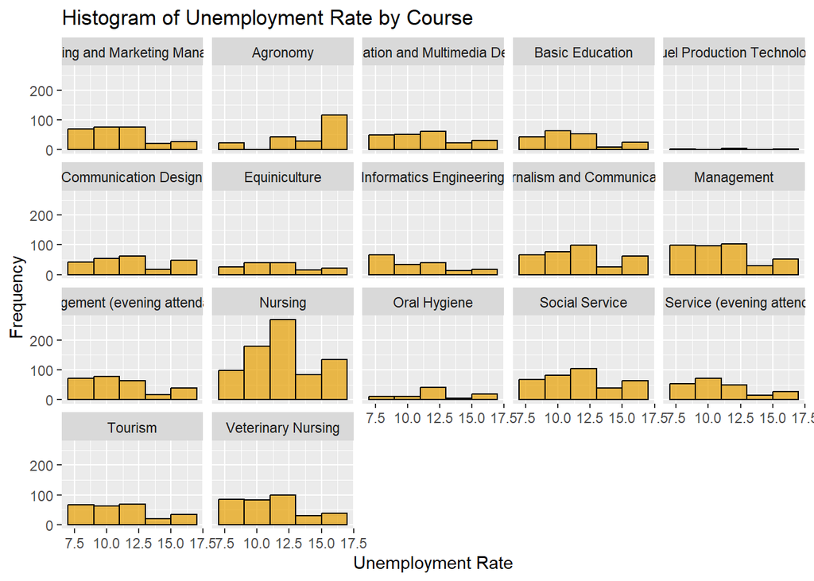

```r
#View Unemployment rate by Course
ggplot(
  data = studentDS1,
  mapping = aes(x = Unemployment.rate)
) +
  geom_histogram(
    color = "black",
    fill = boastPalette[6],
    alpha = 0.7,
    binwidth = 2
  ) +
  facet_wrap(Course~.) +
  labs(
    title = "Histogram of Unemployment Rate by Course",
   x = "Unemployment Rate",
   y = "Frequency"
  )
```

**Comments:**

### MultiLevel Model

```r
#Create MultiLevel Model
Umodel <- lmer(Unemployment.rate ~ Marital.status + Nationality + Application.mode + Previous.qualification + Mother.s.qualification + Father.s.qualification + Mother.s.occupation + Father.s.occupation + (1 | Course), data = studentDS1)
```

```r
#Display model summary
summary(Umodel)
```

```
## Linear mixed model fit by REML ['lmerMod']
## Formula: Unemployment.rate ~ Marital.status + Nationality + Application.mode +
##     Previous.qualification + Mother.s.qualification + Father.s.qualification +
##     Mother.s.occupation + Father.s.occupation + (1 | Course)
##    Data: studentDS1
##
## REML criterion at convergence: 19851.4
##
## Scaled residuals:
##      Min       1Q   Median       3Q      Max
## -2.52212 -0.76308 -0.04534  0.64111  2.43280
##
## Random effects:
##  Groups   Name        Variance Std.Dev.
##  Course   (Intercept) 0.3195   0.5652
##  Residual             5.7634   2.4007
## Number of obs: 4424, groups:  Course, 17
##
## Fixed effects:
##                                                                                                                         Estimate
## (Intercept)                                                                                                              2.76492
## Marital.statusFacto union                                                                                               -0.37933
## Marital.statusLegally separated                                                                                          0.70751
## Marital.statusMarried                                                                                                   -0.14876
## Marital.statusSingle                                                                                                     0.29072
## Marital.statusWidower                                                                                                   -1.19108
## NationalityBrazilian                                                                                                     4.54859
## NationalityCape Verdean                                                                                                  4.79485
## NationalityColombian                                                                                                     4.17108
## NationalityCuban                                                                                                         2.95294
## NationalityDutch                                                                                                         3.84575
## NationalityEnglish                                                                                                       9.78447
## NationalityGerman                                                                                                        3.76781
## NationalityGuinean                                                                                                       3.25126
## NationalityItalian                                                                                                       5.38734
## NationalityLithuanian                                                                                                    9.11188
## NationalityMexican                                                                                                       8.42237
## NationalityMoldova (Republic of)                                                                                         2.94901
## NationalityMozambican                                                                                                    8.46675
## NationalityPortuguese                                                                                                    4.94108
```

[output cut: 551 more lines]

```
## Father.s.occupationSkilled Workers in Industry, Construction, and Craftsmen                                               1.386
## Father.s.occupationSkilled workers in metallurgy, metalworking, and similar                                              -1.469
## Father.s.occupationSpecialists in Intellectual and Scientific Activities                                                  1.044
## Father.s.occupationSpecialists in the physical sciences, mathematics, engineering, and related techniques                -1.547
## Father.s.occupationStreet vendors (except food) and street service providers                                             -1.262
## Father.s.occupationStudent                                                                                                0.057
## Father.s.occupationTeachers                                                                                              -0.857
## Father.s.occupationTechnicians and professionals of intermediate level of health                                         -1.875
## Father.s.occupationUnskilled Workers                                                                                      1.139
## Father.s.occupationUnskilled workers in agriculture, animal production, and fisheries and forestry                       -1.179
## Father.s.occupationUnskilled workers in extractive industry, construction, manufacturing, and transport                  -1.323
## Father.s.occupationVehicle drivers and mobile equipment operators                                                        -1.067
## Father.s.occupationWorkers in food processing, woodworking, clothing and other industries and crafts                     -1.649
## fit warnings:
## fixed-effect model matrix is rank deficient so dropping 2 columns / coefficients
```

**Comments**

- **Model Complexity**: The model includes a relatively large number of predictor variables, encompassing factors such as marital status, nationality, previous qualification, and parental qualifications and occupations. This complexity can potentially lead to overfitting and difficulties in model interpretation.
- **Random Effects**: Random intercepts are included for the effect of `Course`, indicating that there is variability in the intercepts across different courses. This acknowledges the nested structure of the data, where students are clustered within courses. The estimated variance of the random intercepts is 0.3195, suggesting that there is variability in the intercepts among courses.
- **Model Fit**: The REML criterion at convergence is 19851.4, providing a measure of the model’s goodness of fit. Lower values of the REML criterion indicate better fit, although the absolute value itself does not offer a straightforward interpretation. However, it can be used for model comparison, where models with lower REML values are preferred if they provide a similar level of explanatory power.

We’ve found that the unemployment rates can vary across different courses. This means that even if two students have similar backgrounds and characteristics, they might still have different chances of being unemployed depending on the course they’re enrolled in. It’s like saying that the environment or atmosphere of the course they’re taking can also play a role in their employment outcomes. Overall, our analysis highlights the importance of considering various factors beyond just academic performance when understanding students’ employment outcomes, and it underscores the need for tailored support and interventions to ensure every student has the opportunity to thrive in their education and future career.

## Conclusion

- In conclusion, our project has provided valuable insights into the complex interplay of factors influencing student employment outcomes in higher education. Through the application of sophisticated statistical modeling techniques, we have elucidated the multifaceted nature of student success, considering demographic, socioeconomic, and academic performance indicators.